# Проект Обучение с учителем качество модели - git

```python
df_sniz = merge_df_full[merge_df_full['покупательская_активность'] == 'Снизилась']
df_preg = merge_df_full[merge_df_full['покупательская_активность'] == 'Прежний уровень']

# Выравниваем количество записей
df_preg_sampled = df_preg.sample(n=len(df_sniz), random_state=42)

# Объединяем обратно два сбалансированных набора данных
df_balanced = pd.concat([df_sniz, df_preg_sampled])

# Перемешиваем записи, чтобы избежать упорядоченности
df_balanced = df_balanced.sample(frac=1, random_state=42).reset_index(drop=True)

# Теперь df_balanced содержит равное количество записей для двух целевых признаков
print(df_balanced['покупательская_активность'].value_counts())
```

```
Прежний уровень    497
Снизилась          497
Name: покупательская_активность, dtype: int64
```

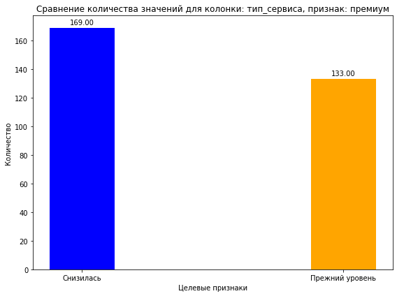

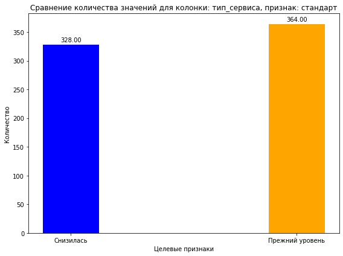

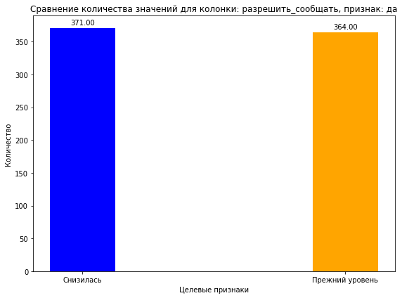

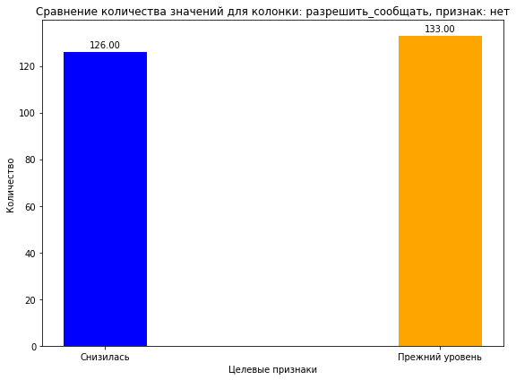

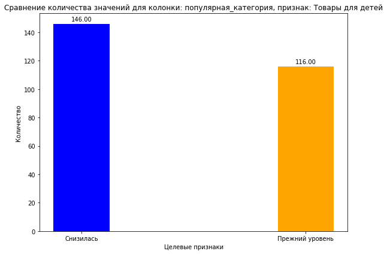

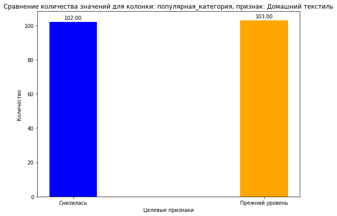

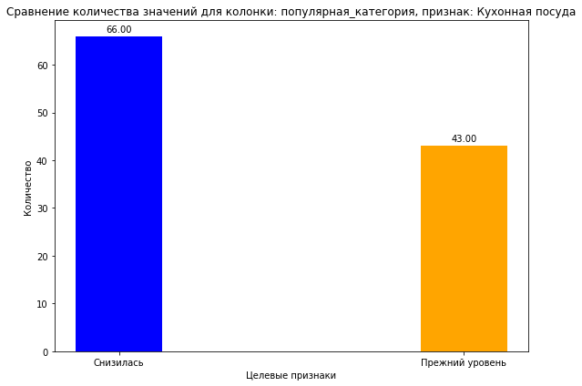

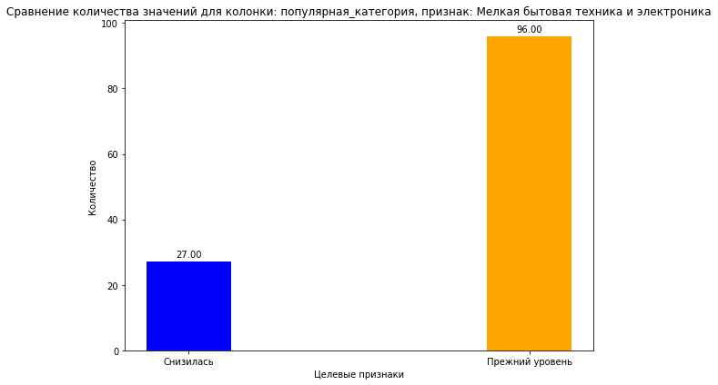

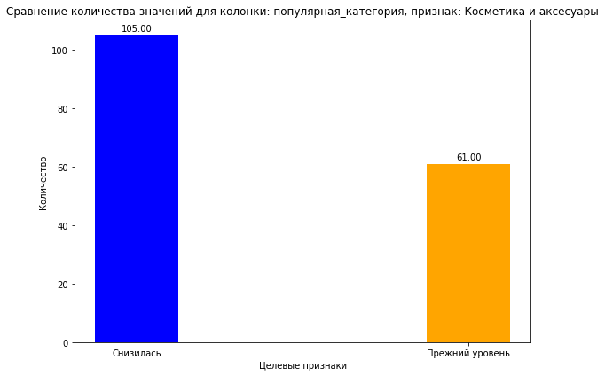

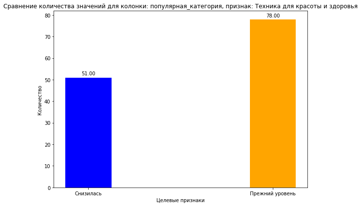

```python
for row in col:
    for i in df_balanced[row].unique():
        # Вычисляем средние значения для каждого целевого признака по текущей колонке
        p_1 = df_balanced.loc[(df_balanced['покупательская_активность'] == 'Снизилась')&(df_balanced[row] == i)].count()[0]
        p_2 = df_balanced.loc[(df_balanced['покупательская_активность'] == 'Прежний уровень')&(df_balanced[row] == i)].count()[0]

        # Построение графика для текущей колонки
        x = np.array([0, 0.2])  # два столбца: один для 'Снизилась', другой для 'Прежний уровень'
        width = 0.05  # ширина столбцов

        # Создаем график
        fig, ax = plt.subplots(figsize=(8, 6))

        # Столбцы для p_1 и p_2
        bars = ax.bar(x, [p_1, p_2], width, color=['blue', 'orange'])

        # Настройки осей и легенды
        ax.set_xlabel('Целевые признаки')
        ax.set_ylabel('Количество')
        ax.set_title(f'Сравнение количества значений для колонки: {row}, признак: {i}')
        ax.set_xticks(x)
        ax.set_xticklabels(['Снизилась', 'Прежний уровень'])

        # Добавление значений над столбцами
        def add_labels(bars):
            for bar in bars:
                height = bar.get_height()
                ax.annotate(f'{height:.2f}',  # форматируем число с двумя знаками после запятой
                            xy=(bar.get_x() + bar.get_width() / 2, height),  # позиция текста
                            xytext=(0, 3),  # небольшое смещение вверх
                            textcoords="offset points",
                            ha='center', va='bottom')

        add_labels(bars)

        plt.tight_layout()
        plt.show()
```

**Различие между группами по целевому признаку:**

Пользователи с прежним уровнем покупательской активности

- Имели больше маркетинговых коммуникаций с команией в течение 6 предыдущих месяцев
- Покупают меньше по акции
- Больше смотрят товаров
- Имеют больший процент выкупа товаров из корзины
- Покупают чаще бытовую технику

У клиентов, которых снизилась активность по покупка, больше таких категорий, как:

- Косметика и аксессуары
- Кухонная посуда
- Товары для детей

Ощущение, что в данной категории больше женщин, а в первой мужчин

## Корреляционный анализ

```python
merge_df_full.drop('id', axis = 1).corr()
```

|  | маркет_актив_6_мес | маркет_актив_тек_мес | длительность | акционные_покупки | средний_просмотр_категорий_за_визит | неоплаченные_продукты_штук_квартал | ошибка_сервиса | страниц_за_визит | предыдущий_месяц_x | препредыдущий_месяц | текущий_месяц_x | предыдущий_месяц_y | текущий_месяц_y |
| --- | --- | --- | --- | --- | --- | --- | --- | --- | --- | --- | --- | --- | --- |
| маркет_актив_6_мес | 1.000000 | 0.057578 | -0.037586 | -0.237697 | 0.201671 | -0.165088 | 0.034562 | 0.314849 | 0.023002 | 0.207673 | 0.014180 | 0.288188 | 0.222614 |
| маркет_актив_тек_мес | 0.057578 | 1.000000 | -0.139361 | -0.009750 | -0.021235 | 0.054015 | 0.088259 | 0.001759 | -0.053914 | -0.073933 | -0.018816 | 0.010386 | -0.068592 |
| длительность | -0.037586 | -0.139361 | 1.000000 | 0.017473 | -0.057805 | -0.091003 | 0.110578 | -0.034641 | 0.038700 | 0.011058 | 0.019036 | -0.120726 | 0.094862 |
| акционные_покупки | -0.237697 | -0.009750 | 0.017473 | 1.000000 | -0.172336 | 0.192650 | -0.025224 | -0.303038 | 0.015153 | -0.130630 | 0.016825 | -0.270059 | -0.215494 |
| средний_просмотр_категорий_за_визит | 0.201671 | -0.021235 | -0.057805 | -0.172336 | 1.000000 | -0.274896 | 0.004032 | 0.237534 | -0.049440 | 0.093775 | -0.077803 | 0.134991 | 0.225339 |
| неоплаченные_продукты_штук_квартал | -0.165088 | 0.054015 | -0.091003 | 0.192650 | -0.274896 | 1.000000 | -0.091192 | -0.193705 | -0.001104 | -0.208367 | 0.039147 | -0.182746 | -0.206591 |
| ошибка_сервиса | 0.034562 | 0.088259 | 0.110578 | -0.025224 | 0.004032 | -0.091192 | 1.000000 | 0.086813 | 0.033817 | 0.055563 | 0.036171 | 0.186052 | 0.070601 |
| страниц_за_визит | 0.314849 | 0.001759 | -0.034641 | -0.303038 | 0.237534 | -0.193705 | 0.086813 | 1.000000 | -0.021396 | 0.268851 | -0.027541 | 0.425091 | 0.255391 |
| предыдущий_месяц_x | 0.023002 | -0.053914 | 0.038700 | 0.015153 | -0.049440 | -0.001104 | 0.033817 | -0.021396 | 1.000000 | 0.438461 | 0.803038 | -0.058093 | -0.039125 |
| препредыдущий_месяц | 0.207673 | -0.073933 | 0.011058 | -0.130630 | 0.093775 | -0.208367 | 0.055563 | 0.268851 | 0.438461 | 1.000000 | 0.118188 | 0.290693 | 0.264220 |
| текущий_месяц_x | 0.014180 | -0.018816 | 0.019036 | 0.016825 | -0.077803 | 0.039147 | 0.036171 | -0.027541 | 0.803038 | 0.118188 | 1.000000 | -0.138728 | -0.162677 |
| предыдущий_месяц_y | 0.288188 | 0.010386 | -0.120726 | -0.270059 | 0.134991 | -0.182746 | 0.186052 | 0.425091 | -0.058093 | 0.290693 | -0.138728 | 1.000000 | 0.349542 |
| текущий_месяц_y | 0.222614 | -0.068592 | 0.094862 | -0.215494 | 0.225339 | -0.206591 | 0.070601 | 0.255391 | -0.039125 | 0.264220 | -0.162677 | 0.349542 | 1.000000 |

```
interval columns not set, guessing: ['маркет_актив_6_мес', 'маркет_актив_тек_мес', 'длительность', 'акционные_покупки', 'средний_просмотр_категорий_за_визит', 'неоплаченные_продукты_штук_квартал', 'ошибка_сервиса', 'страниц_за_визит', 'предыдущий_месяц_x', 'препредыдущий_месяц', 'текущий_месяц_x', '…
```

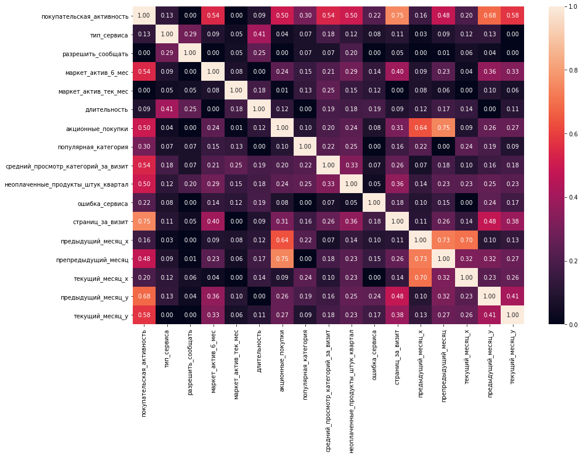

```python
fig, ax = plt.subplots(figsize=(15, 10))
sns.heatmap(merge_df_full.drop('id', axis=1).phik_matrix(), annot=True, fmt='.2f')
```

```python
# преобразуем качественные значения в количественные и нормализуем данные. Посмотрим на кор.анализ под таким углом
# Выделим количественные и качественные данные в выборке
merge_df_full_col = copy.deepcopy(merge_df_full).drop('id', axis = 1).select_dtypes(include=np.number)
merge_df_full_kach = copy.deepcopy(merge_df_full).drop('id', axis = 1).select_dtypes(exclude=np.number)
```

Построим диаграмму рассеивания целевого признака (покупательская активность) от входных параметров

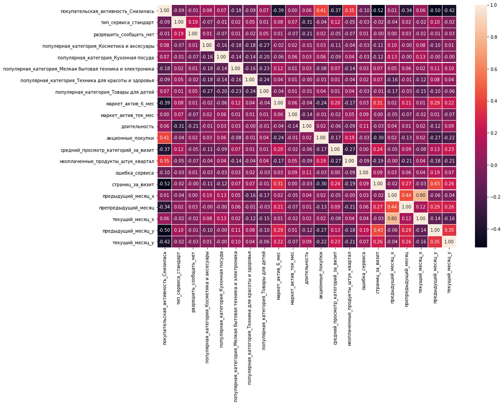

```python
# создайте переменную с экземпляром класса StandardScaler
scaler = StandardScaler()

# обучите и трансформируйте количественные признаки из тренировочной выборки
# сделайте это одной командой
X_train_scaled = scaler.fit_transform(merge_df_full_col)

# создайте переменную с экземпляром класса OneHotEncoder
# включите параметр для избегания появления дамми-ошибок,
encoder = OneHotEncoder(drop='first')

# обучите и трансформируйте категориальные признаки из тренировочной выборки
# сделайте это одной командой
X_train_ohe = encoder.fit_transform(merge_df_full_kach)

# получите от кодировщика список новых столбцов и сохраните в новой переменной
encoder_col_names = encoder.get_feature_names_out()

# создаём тренировочный и тестовый датафреймы из закодированных и отмасштабированных данных
# для данных OHE названия столбцов укажите из переменной encoder_col_names
X_train_ohe = pd.DataFrame(X_train_ohe.toarray(), columns=encoder_col_names)

X_train_scaled = pd.DataFrame(X_train_scaled, columns=merge_df_full_col.columns)

# объединяем все преобразованные данные в тренировочный датафрейм
X_train = pd.concat([X_train_ohe, X_train_scaled], axis=1)

# визуализация тепловой карты корреляции
fig, ax = plt.subplots(figsize=(15, 10))
sns.heatmap(X_train.corr(), annot=True, fmt='.2f', linewidths=.3)
```

```python
# Преобразуем целевой признак в числовой
df_corr = copy.deepcopy(merge_df_full)
# Создаем список соответствий для кодирования
mapping = {'Снизилась': 1, 'Прежний уровень': 0}
# Преобразование столбца в матрицу
df_corr['покупательская_активность'] = df_corr['покупательская_активность'].map(lambda x: mapping[x])
```

```
Строим зависимость по покупательская_активность маркет_актив_6_мес
Категориальный признак:  покупательская_активность
Тип:  1
Тип:  0
```

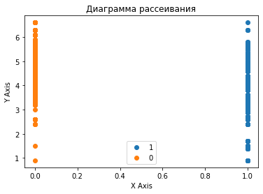

```
Категориальный признак:  тип_сервиса
Тип:  премиум
Тип:  стандарт
```

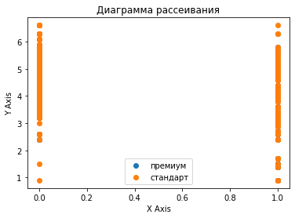

```
Категориальный признак:  разрешить_сообщать
Тип:  да
Тип:  нет
```

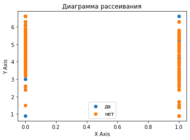

```
Категориальный признак:  популярная_категория
Тип:  Товары для детей
Тип:  Домашний текстиль
Тип:  Косметика и аксесуары
Тип:  Техника для красоты и здоровья
Тип:  Кухонная посуда
Тип:  Мелкая бытовая техника и электроника
```

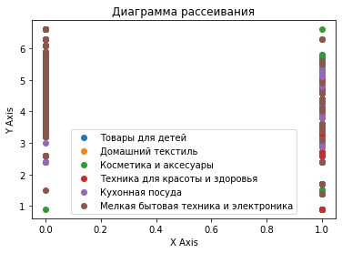

```
Строим зависимость по покупательская_активность маркет_актив_тек_мес
Категориальный признак:  покупательская_активность
Тип:  1
Тип:  0
```

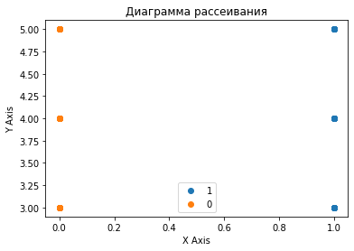

```
Категориальный признак:  тип_сервиса
Тип:  премиум
Тип:  стандарт
```

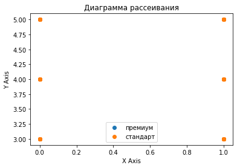

```
Категориальный признак:  разрешить_сообщать
Тип:  да
Тип:  нет
```

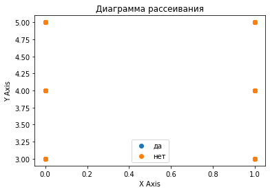

```
Категориальный признак:  популярная_категория
Тип:  Товары для детей
Тип:  Домашний текстиль
Тип:  Косметика и аксесуары
Тип:  Техника для красоты и здоровья
Тип:  Кухонная посуда
Тип:  Мелкая бытовая техника и электроника
```

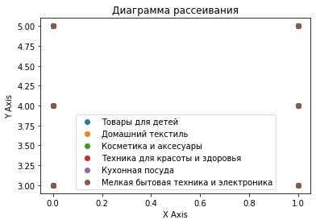

```
Строим зависимость по покупательская_активность длительность
Категориальный признак:  покупательская_активность
Тип:  1
Тип:  0
```

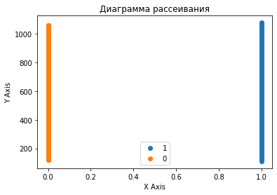

```
Категориальный признак:  тип_сервиса
Тип:  премиум
Тип:  стандарт
```

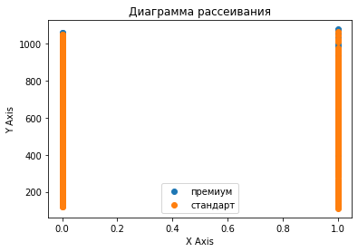

```
Категориальный признак:  разрешить_сообщать
Тип:  да
Тип:  нет
```

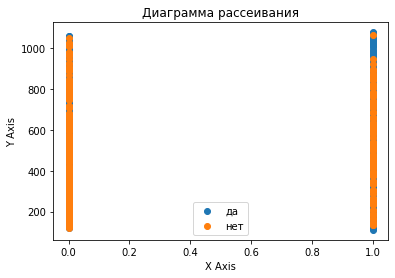

```
Категориальный признак:  популярная_категория
Тип:  Товары для детей
Тип:  Домашний текстиль
Тип:  Косметика и аксесуары
Тип:  Техника для красоты и здоровья
Тип:  Кухонная посуда
Тип:  Мелкая бытовая техника и электроника
```

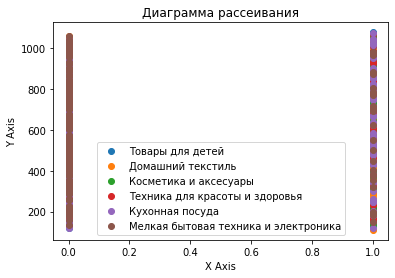

```
Строим зависимость по покупательская_активность акционные_покупки
Категориальный признак:  покупательская_активность
Тип:  1
Тип:  0
```

[40 more figures not shown]

```python
cat_col_names = merge_df_full_kach.columns
num_col_names = merge_df_full_col.columns

# Заходим в количественные признаки
for row in num_col_names:
    print('Строим зависимость по покупательская_активность',row)
# Заходим в категориальные признаки
    for row_1 in cat_col_names:
        print('Категориальный признак: ',row_1)
# Берем категориальный признак и находим уникальное значение для него
        for row_2 in df_corr[row_1].unique():
            print('Тип: ',row_2)
            x = df_corr.loc[df_corr[row_1]==row_2]['покупательская_активность']
            y = df_corr.loc[df_corr[row_1]==row_2][row]
            plt.scatter(x, y, label=row_2)
            # Добавление легенды
        plt.legend()

        # Настройка осей
        plt.xlabel('X Axis')
        plt.ylabel('Y Axis')

        # Название графика
        plt.title('Диаграмма рассеивания')

        # Показ графика
        plt.show()
        #for row in col:
```

**Вывод:**

1. Провел корреляционный анализ. Мультиколлинеарности не наблюдается. Есть признаки, которые имеют обратную зависимость
2. Преобразовал целевой признак в числовой. Сделал анализ рассеивания. Ничего полезного из этого извлечь нельзя. Так как данный вид анализа больше подходит для чисел, которые имеют линейную зависимость (непрерывные числа)

```python
merge_df_full_copy = copy.deepcopy(merge_df_full)
merge_df_full_copy
```

|  | id | покупательская_активность | тип_сервиса | разрешить_сообщать | маркет_актив_6_мес | маркет_актив_тек_мес | длительность | акционные_покупки | популярная_категория | средний_просмотр_категорий_за_визит | неоплаченные_продукты_штук_квартал | ошибка_сервиса | страниц_за_визит | предыдущий_месяц_x | препредыдущий_месяц | текущий_месяц_x | предыдущий_месяц_y | текущий_месяц_y |
| --- | --- | --- | --- | --- | --- | --- | --- | --- | --- | --- | --- | --- | --- | --- | --- | --- | --- | --- |
| 0 | 215348 | Снизилась | премиум | да | 3.4 | 5 | 121 | 0.00 | Товары для детей | 6 | 2 | 1 | 5 | 0.0 | 0.0 | 3293.1 | 13 | 14 |
| 1 | 215349 | Снизилась | премиум | да | 4.4 | 4 | 819 | 0.75 | Товары для детей | 4 | 4 | 2 | 5 | 5216.0 | 4472.0 | 4971.6 | 12 | 10 |
| 2 | 215350 | Снизилась | стандарт | нет | 4.9 | 3 | 539 | 0.14 | Домашний текстиль | 5 | 2 | 1 | 5 | 5457.5 | 4826.0 | 5058.4 | 8 | 13 |
| 3 | 215351 | Снизилась | стандарт | да | 3.2 | 5 | 896 | 0.99 | Товары для детей | 5 | 0 | 6 | 4 | 6158.0 | 4793.0 | 6610.4 | 11 | 13 |
| 4 | 215352 | Снизилась | стандарт | нет | 5.1 | 3 | 1064 | 0.94 | Товары для детей | 3 | 2 | 3 | 2 | 5807.5 | 4594.0 | 5872.5 | 8 | 11 |
| ... | ... | ... | ... | ... | ... | ... | ... | ... | ... | ... | ... | ... | ... | ... | ... | ... | ... | ... |
| 1294 | 216643 | Прежний уровень | стандарт | да | 6.6 | 3 | 318 | 0.24 | Техника для красоты и здоровья | 5 | 3 | 3 | 11 | 3664.0 | 4704.0 | 4741.7 | 14 | 7 |
| 1295 | 216644 | Прежний уровень | стандарт | нет | 5.1 | 4 | 454 | 0.21 | Домашний текстиль | 6 | 2 | 3 | 9 | 4729.0 | 5299.0 | 5353.0 | 12 | 11 |
| 1296 | 216645 | Прежний уровень | стандарт | да | 4.1 | 3 | 586 | 0.20 | Домашний текстиль | 3 | 2 | 5 | 7 | 5160.0 | 5334.0 | 5139.2 | 12 | 18 |
| 1297 | 216646 | Прежний уровень | стандарт | да | 6.3 | 5 | 645 | 0.12 | Техника для красоты и здоровья | 3 | 3 | 5 | 7 | 4923.0 | 4725.0 | 5224.6 | 18 | 7 |
| 1298 | 216647 | Прежний уровень | премиум | да | 4.0 | 5 | 906 | 0.94 | Техника для красоты и здоровья | 4 | 5 | 3 | 12 | 4720.0 | 5183.0 | 4448.3 | 15 | 10 |

1299 rows × 18 columns

```python
merge_df_full_copy.columns
```

```
Index(['id', 'покупательская_активность', 'тип_сервиса', 'разрешить_сообщать',
       'маркет_актив_6_мес', 'маркет_актив_тек_мес', 'длительность',
       'акционные_покупки', 'популярная_категория',
       'средний_просмотр_категорий_за_визит',
       'неоплаченные_продукты_штук_квартал', 'ошибка_сервиса',
       'страниц_за_визит', 'предыдущий_месяц_x', 'препредыдущий_месяц',
       'текущий_месяц_x', 'предыдущий_месяц_y', 'текущий_месяц_y'],
      dtype='object')
```

## Использование пайплайнов

```python
RANDOM_STATE = 42
TEST_SIZE = 0.25

X_train, X_test, y_train, y_test = train_test_split(
    merge_df_full_copy.drop(['id','покупательская_активность'], axis=1),
    merge_df_full_copy['покупательская_активность'],
    test_size = TEST_SIZE,
    random_state = RANDOM_STATE,
    stratify = merge_df_full_copy['покупательская_активность'])

X_train.shape, X_test.shape
```

```
((974, 16), (325, 16))
```

Кодируем данные из категориальной в числовое

```python
label_encoder = LabelEncoder()
y_train_encoded = label_encoder.fit_transform(y_train)
y_test_encoded = label_encoder.transform(y_test)
```

```python
for i, class_name in enumerate(label_encoder.classes_):
    print(f'Категория: {class_name} -> Кодировка: {i}')
```

```
Категория: Прежний уровень -> Кодировка: 0
Категория: Снизилась -> Кодировка: 1
```

```python
# создаём списки с названиями признаков
ohe_columns = ['тип_сервиса','разрешить_сообщать','популярная_категория']
num_columns = ['маркет_актив_6_мес','маркет_актив_тек_мес','длительность','акционные_покупки',\
               'средний_просмотр_категорий_за_визит','неоплаченные_продукты_штук_квартал','ошибка_сервиса',\
              'страниц_за_визит','предыдущий_месяц_x','препредыдущий_месяц','текущий_месяц_x',\
              'предыдущий_месяц_y','текущий_месяц_y']
```

```python
!pip install scikit-learn
```

```python
!pip install scikit-learn==1.1.3 -q
```

```python
# Пайплайн для подготовки категориальных признаков
ohe_pipe = Pipeline([
    ('simpleImputer_ohe', SimpleImputer(missing_values=np.nan, strategy='most_frequent')),
    ('ohe', OneHotEncoder(drop='first', handle_unknown='ignore', sparse=False))
])

# ColumnTransformer для обработки признаков
data_preprocessor = ColumnTransformer([
    ('ohe', ohe_pipe, ohe_columns),
    ('num', Pipeline([
        ('simpleImputer_num', SimpleImputer(strategy='median')),  # Импьютация для числовых
        ('scaler', StandardScaler())  # Скалирование для числовых
    ]), num_columns)
], remainder='passthrough')

# Итоговый пайплайн: подготовка данных и модель
pipe_final = Pipeline([
    ('preprocessor', data_preprocessor),
    ('models', DecisionTreeClassifier(random_state=RANDOM_STATE))  # Заглушка для модели
])

# Сетка гиперпараметров с добавленной моделью SVC
param_grid = [
    # DecisionTreeClassifier
    {
        'models': [DecisionTreeClassifier(random_state=RANDOM_STATE)],
        'models__max_depth': range(2, 5),
        'models__max_features': range(2, 5),
        'preprocessor__num__scaler': [StandardScaler(), MinMaxScaler(), RobustScaler(), 'passthrough']
    },

    # KNeighborsClassifier
    {
        'models': [KNeighborsClassifier()],
        'models__n_neighbors': range(2, 5),
        'preprocessor__num__scaler': [StandardScaler(), MinMaxScaler(), RobustScaler(), 'passthrough']
    },

    # LogisticRegression
    {
        'models': [LogisticRegression(random_state=RANDOM_STATE, solver='liblinear', penalty='l1')],
        'models__C': range(1, 5),
        'preprocessor__num__scaler': [StandardScaler(), MinMaxScaler(), RobustScaler(), 'passthrough']
    },

    # SVC
    {
        'models': [SVC(probability=True)],
        'models__C': range(1, 5),  # Параметр регуляризации
        'models__kernel': ['linear', 'rbf', 'sigmoid', 'poly'],  # Тип ядра
        'models__degree': range(1, 6),  # Степень полиномиального ядра (применяется только для poly)
        'preprocessor__num__scaler': [StandardScaler(), MinMaxScaler(), RobustScaler(), 'passthrough']
    }
]

# RandomizedSearchCV для поиска лучших параметров
randomized_search = RandomizedSearchCV(
    pipe_final,
    param_grid,
    cv=5,
    scoring='roc_auc',
    random_state=RANDOM_STATE,
    n_jobs=-1
)

# Обучение модели
randomized_search.fit(X_train, y_train_encoded)

# Вывод лучшей модели и её параметров
print('Лучшая модель и её параметры:\n\n', randomized_search.best_estimator_)
print('Метрика лучшей модели на тренировочной выборке:', randomized_search.best_score_)

# Прогноз вероятностей и оценка на тестовой выборке
y_test_pred_proba = randomized_search.predict_proba(X_test)  # Получаем вероятности
y_test_pred_one = y_test_pred_proba[:, 1]  # Берем вероятности для положительного класса

print(f'Метрика ROC-AUC на тестовой выборке: {roc_auc_score(y_test_encoded, y_test_pred_one)}')
```

```
Лучшая модель и её параметры:

 Pipeline(steps=[('preprocessor',
                 ColumnTransformer(remainder='passthrough',
                                   transformers=[('ohe',
                                                  Pipeline(steps=[('simpleImputer_ohe',
                                                                   SimpleImputer(strategy='most_frequent')),
                                                                  ('ohe',
                                                                   OneHotEncoder(drop='first',
                                                                                 handle_unknown='ignore',
                                                                                 sparse=False))]),
                                                  ['тип_сервиса',
                                                   'разрешить_сообщать',
                                                   'популярная_категория']),
                                                 ('num',
                                                  Pipeline(steps=[('simpleImputer_nu...
                                                                   StandardScaler())]),
                                                  ['маркет_актив_6_мес',
                                                   'маркет_актив_тек_мес',
                                                   'длительность',
                                                   'акционные_покупки',
                                                   'средний_просмотр_категорий_за_визит',
                                                   'неоплаченные_продукты_штук_квартал',
                                                   'ошибка_сервиса',
                                                   'страниц_за_визит',
                                                   'предыдущий_месяц_x',
                                                   'препредыдущий_месяц',
                                                   'текущий_месяц_x',
                                                   'предыдущий_месяц_y',
                                                   'текущий_месяц_y'])])),
                ('models', SVC(C=4, degree=5, probability=True))])
Метрика лучшей модели на тренировочной выборке: 0.909787307969126
Метрика ROC-AUC на тестовой выборке: 0.9184721553522709
```

```python
# Получаем лучшую модель SVC
best_model = randomized_search.best_estimator_.named_steps['models']

# Выводим тип ядра, который был использован
print(f'Использованное ядро: {best_model.kernel}')
```

```
Использованное ядро: rbf
```

```python
randomized_search.best_estimator_.named_steps['models']
```

```
SVC(C=4, degree=5, probability=True)
```

**Вывод:**

- Было проверено 4 модели с различными гиперпараметрами. Лучшая модель **SVC(C=4, degree=5, probability=True) с ядром rbf scaler = StandardScaler()**
- Для оценки качества модели использовалась метрика **ROC-AUC**. Данная метрика более универсальная, и используется при оценке двух классов. Учитывает как правильное предсказание, так и минимизацию ложных предсказаний. Хорошо работает даже при несбалансированных данных, где классы распределены неравномерно.
- Рассматривает различные пороги классификации, оценивая качество предсказаний при разных значениях порога. Это делает её более универсальной. Позволяет сравнивать разные модели между собой на основе вероятностей.

**ROC-AUC тестовой выше, чем тренировочная**:

- Правильно настроенные гиперпараметры и хорошо сбалансированная модель могут демонстрировать стабильные или даже немного лучшие результаты на тестовых данных
- Лёгкое повышение метрики на тестовой выборке также может быть результатом случайных отклонений (например, тестовая выборка могла быть немного проще, чем тренировочная
- В ходе подбора гиперпараметров использовалась рандомизация через RandomizedSearchCV, это также может помочь улучшить обобщающую способность модели, так как модель проверялась на разных подвыборках данных.

## Анализ важности признаков

Построим график **beeswarm** (отображает вклад всех признаков в классификацию каждого наблюдения) и **bar** (показывает общую важность признаков модели).

```python
# Определение лучшей модели
best_model = randomized_search.best_estimator_

# Найдём саму модель в конвейере
actual_model = best_model.named_steps["models"]

# Преобразуем тренировочные данные с помощью тех же трансформаций, что и при обучении
X_train_transformed = best_model.named_steps["preprocessor"].transform(X_train)
X_train_transformed = X_train_transformed[0:100]

ohe_feature_names = best_model.named_steps['preprocessor'].transformers_[0][1]\
    .named_steps['ohe'].get_feature_names(ohe_columns)

# 2. Имена числовых признаков
num_feature_names = num_columns

# Объединяем все имена признаков
feature_names = list(ohe_feature_names) + num_feature_names

# Выбор правильного объяснителя SHAP в зависимости от типа модели
if isinstance(actual_model, LogisticRegression):
    explainer = shap.LinearExplainer(actual_model, X_train_transformed)
elif isinstance(actual_model, (DecisionTreeClassifier, KNeighborsClassifier)):
    explainer = shap.TreeExplainer(actual_model)
elif isinstance(actual_model, SVC):
    explainer = shap.KernelExplainer(actual_model.predict, X_train_transformed)
else:
    raise ValueError("Неизвестный тип модели для SHAP")

# Получение значений SHAP
shap_values = explainer.shap_values(X_train_transformed)
```

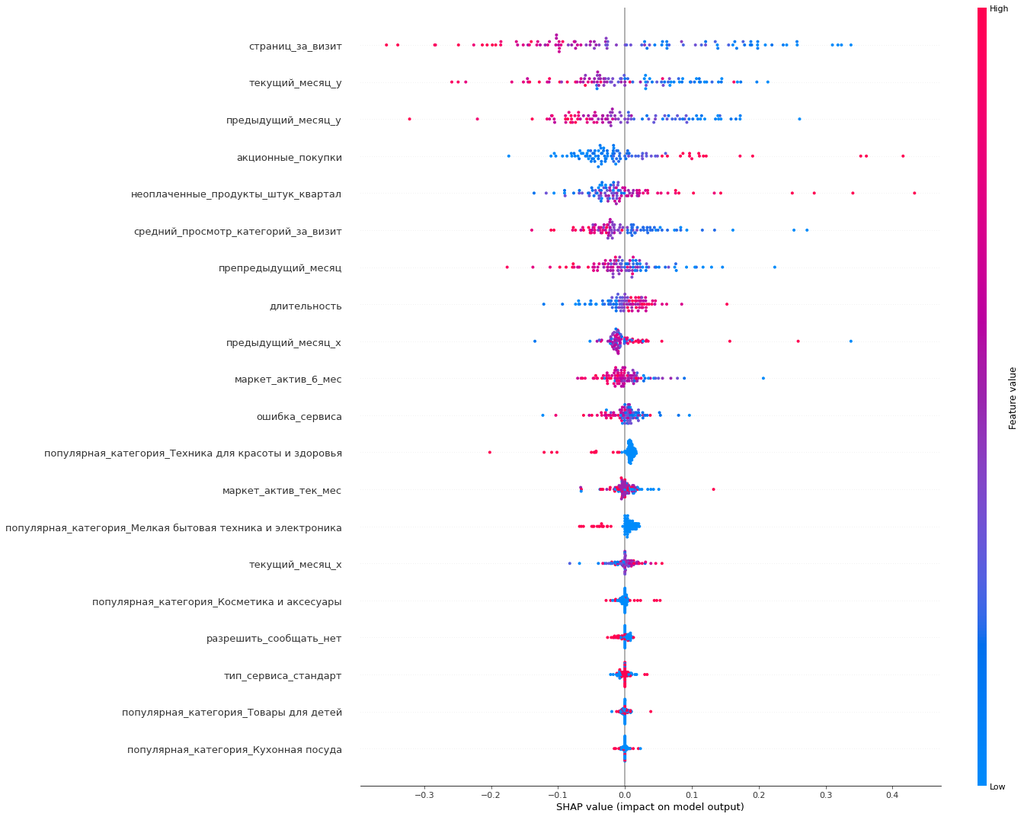

```python
shap.summary_plot(shap_values, X_train_transformed, feature_names=feature_names,plot_size=(20, 15))
```

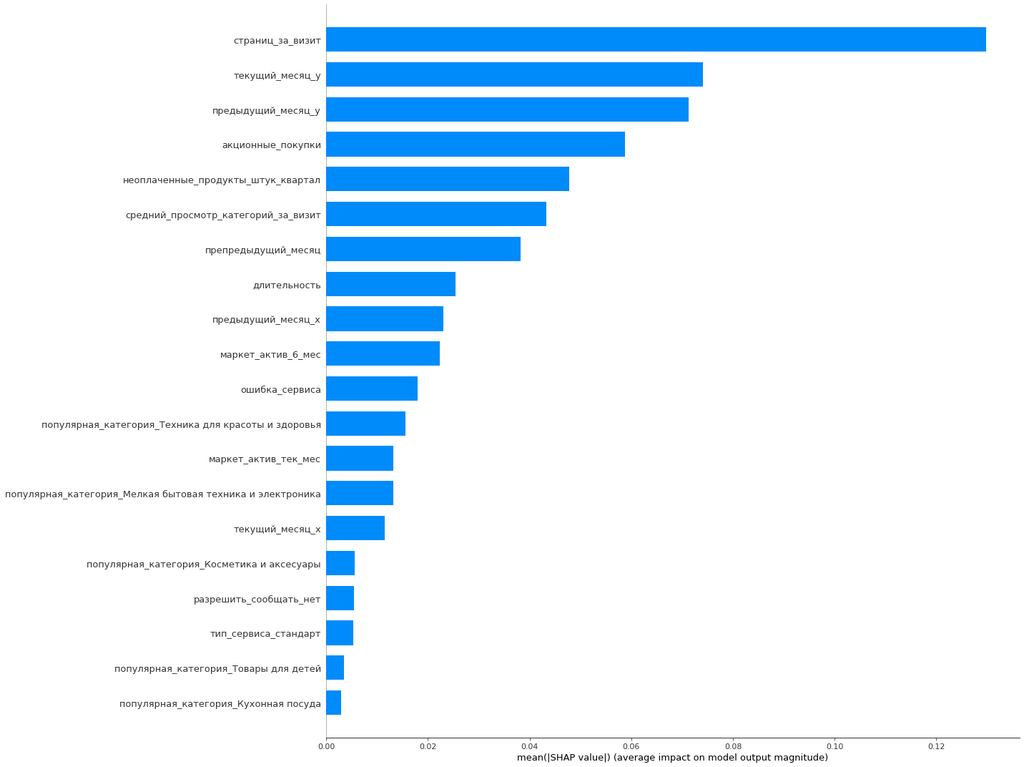

```python
shap.summary_plot(shap_values, X_train_transformed, feature_names=feature_names, plot_type = 'bar', plot_size=(20, 15))
```

## Сегментация покупателей

Сегментируем клиентов по следующим показателям:

**1. Частота покупок**

- часто (>=2 за 3 месяца)
- редко (1 раз за 3 месяца)

**2. Объем выручки**

- выше среднего (высокий)
- низкий (меньше среднего)

Сегмент 1 = Часто - Высокий

Сегмент 2 = Часто - Низкий

Сегмент 3 = Редко - Высокий

Сегмент 4 = Редко - Низкий

```python
from sklearn.cluster import KMeans # метод кластеризации
```

```python
merge_df_full_copy.columns
```

```
Index(['id', 'покупательская_активность', 'тип_сервиса', 'разрешить_сообщать',
       'маркет_актив_6_мес', 'маркет_актив_тек_мес', 'длительность',
       'акционные_покупки', 'популярная_категория',
       'средний_просмотр_категорий_за_визит',
       'неоплаченные_продукты_штук_квартал', 'ошибка_сервиса',
       'страниц_за_визит', 'предыдущий_месяц_x', 'препредыдущий_месяц',
       'текущий_месяц_x', 'предыдущий_месяц_y', 'текущий_месяц_y'],
      dtype='object')
```

```python
merge_df_full_copy_cl = copy.deepcopy(merge_df_full_copy)
```

```python
merge_df_cluster = merge_df_full_copy_cl.merge(money, on = 'id', how = 'left')
```

```python
merge_df_cluster['препредыдущий_месяц'] = merge_df_cluster['препредыдущий_месяц'].apply(lambda x: 0 if x <= 0 else 1)
merge_df_cluster['предыдущий_месяц_x'] = merge_df_cluster['предыдущий_месяц_x'].apply(lambda x: 0 if x <= 0 else 1)
merge_df_cluster['текущий_месяц_x'] = merge_df_cluster['текущий_месяц_x'].apply(lambda x: 0 if x <= 0 else 1)
```

```python
merge_df_cluster['частота'] = merge_df_cluster.apply(lambda row: 'Часто' if row['препредыдущий_месяц'] + row['предыдущий_месяц_x'] + row['текущий_месяц_x'] >= 2 else 'Редко', axis=1)
```

```python
# Рассчитываем среднее значение прибыли
mean_profit = merge_df_cluster['прибыль'].mean()

# Применяем lambda функцию для сравнения с общим средним значением
merge_df_cluster['кат_прибыли'] = merge_df_cluster['прибыль'].apply(lambda x: 'Высокая прибыль' if x > mean_profit else 'Низкая прибыль')
```

```python
# Функция для определения сегмента
def segment(row):
    if row['частота'] == 'Часто' and row['кат_прибыли'] == 'Высокая прибыль':
        return 'Сегмент 1'
    elif row['частота'] == 'Часто' and row['кат_прибыли'] == 'Низкая прибыль':
        return 'Сегмент 2'
    elif row['частота'] == 'Редко' and row['кат_прибыли'] == 'Высокая прибыль':
        return 'Сегмент 3'
    elif row['частота'] == 'Редко' and row['кат_прибыли'] == 'Низкая прибыль':
        return 'Сегмент 4'
    else:
        return 'Неопределённый сегмент'

# Создание нового столбца с сегментами
merge_df_cluster['сегмент'] = merge_df_cluster.apply(segment, axis=1)
```

Выберу сегмент клиентов, которые совершали много покупок, имеют высокую прибыль и их активность снизилась. Посмотрим сколько таких клиентов и какие категории товаров они чаще всего брали

```python
merge_df_cluster
```

|  | id | покупательская_активность | тип_сервиса | разрешить_сообщать | маркет_актив_6_мес | маркет_актив_тек_мес | длительность | акционные_покупки | популярная_категория | средний_просмотр_категорий_за_визит | ... | страниц_за_визит | предыдущий_месяц_x | препредыдущий_месяц | текущий_месяц_x | предыдущий_месяц_y | текущий_месяц_y | прибыль | частота | кат_прибыли | сегмент |
| --- | --- | --- | --- | --- | --- | --- | --- | --- | --- | --- | --- | --- | --- | --- | --- | --- | --- | --- | --- | --- | --- |
| 0 | 215348 | Снизилась | премиум | да | 3.4 | 5 | 121 | 0.00 | Товары для детей | 6 | ... | 5 | 0 | 0 | 1 | 13 | 14 | 0.98 | Редко | Низкая прибыль | Сегмент 4 |
| 1 | 215349 | Снизилась | премиум | да | 4.4 | 4 | 819 | 0.75 | Товары для детей | 4 | ... | 5 | 1 | 1 | 1 | 12 | 10 | 4.16 | Часто | Высокая прибыль | Сегмент 1 |
| 2 | 215350 | Снизилась | стандарт | нет | 4.9 | 3 | 539 | 0.14 | Домашний текстиль | 5 | ... | 5 | 1 | 1 | 1 | 8 | 13 | 3.13 | Часто | Низкая прибыль | Сегмент 2 |
| 3 | 215351 | Снизилась | стандарт | да | 3.2 | 5 | 896 | 0.99 | Товары для детей | 5 | ... | 4 | 1 | 1 | 1 | 11 | 13 | 4.87 | Часто | Высокая прибыль | Сегмент 1 |
| 4 | 215352 | Снизилась | стандарт | нет | 5.1 | 3 | 1064 | 0.94 | Товары для детей | 3 | ... | 2 | 1 | 1 | 1 | 8 | 11 | 4.21 | Часто | Высокая прибыль | Сегмент 1 |
| ... | ... | ... | ... | ... | ... | ... | ... | ... | ... | ... | ... | ... | ... | ... | ... | ... | ... | ... | ... | ... | ... |
| 1294 | 216643 | Прежний уровень | стандарт | да | 6.6 | 3 | 318 | 0.24 | Техника для красоты и здоровья | 5 | ... | 11 | 1 | 1 | 1 | 14 | 7 | 4.44 | Часто | Высокая прибыль | Сегмент 1 |
| 1295 | 216644 | Прежний уровень | стандарт | нет | 5.1 | 4 | 454 | 0.21 | Домашний текстиль | 6 | ... | 9 | 1 | 1 | 1 | 12 | 11 | 6.11 | Часто | Высокая прибыль | Сегмент 1 |
| 1296 | 216645 | Прежний уровень | стандарт | да | 4.1 | 3 | 586 | 0.20 | Домашний текстиль | 3 | ... | 7 | 1 | 1 | 1 | 12 | 18 | 3.29 | Часто | Низкая прибыль | Сегмент 2 |
| 1297 | 216646 | Прежний уровень | стандарт | да | 6.3 | 5 | 645 | 0.12 | Техника для красоты и здоровья | 3 | ... | 7 | 1 | 1 | 1 | 18 | 7 | 4.03 | Часто | Высокая прибыль | Сегмент 1 |
| 1298 | 216647 | Прежний уровень | премиум | да | 4.0 | 5 | 906 | 0.94 | Техника для красоты и здоровья | 4 | ... | 12 | 1 | 1 | 1 | 15 | 10 | 3.28 | Часто | Низкая прибыль | Сегмент 2 |

1299 rows × 22 columns

```python
cl_1 = copy.deepcopy(merge_df_cluster.loc[(merge_df_cluster['покупательская_активность']=='Снизилась')&\
                    (merge_df_cluster['сегмент']=='Сегмент 1')])
```

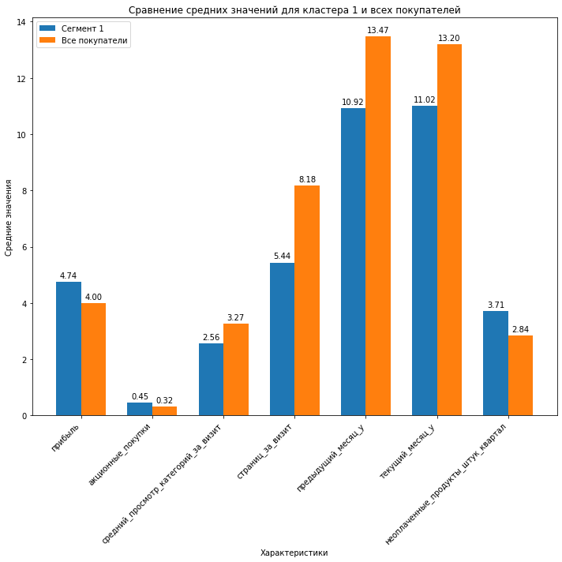

```python
# Список колонок для анализа
col = ['прибыль', 'акционные_покупки', 'средний_просмотр_категорий_за_визит',
       'страниц_за_визит', 'предыдущий_месяц_y', 'текущий_месяц_y',
       'неоплаченные_продукты_штук_квартал']

cluster_1_means = []
overall_means = []

# Собираем данные по средним значениям
for row in col:
    cluster_1_means.append(cl_1[row].mean())
    overall_means.append(merge_df_cluster[row].mean())

# Построение графиков
x = np.arange(len(col))  # позиции для каждого столбца

width = 0.35  # ширина столбцов

# Создаем график
fig, ax = plt.subplots(figsize=(10, 10))

# Столбцы для кластера 2
bars1 = ax.bar(x - width/2, cluster_1_means, width, label='Сегмент 1')

# Столбцы для всех данных
bars2 = ax.bar(x + width/2, overall_means, width, label='Все покупатели')

# Настройки осей и легенды
ax.set_xlabel('Характеристики')
ax.set_ylabel('Средние значения')
ax.set_title('Сравнение средних значений для кластера 1 и всех покупателей')
ax.set_xticks(x)
ax.set_xticklabels(col, rotation=45, ha="right")
ax.legend()

# Добавление значений над столбцами
def add_labels(bars):
    for bar in bars:
        height = bar.get_height()
        ax.annotate(f'{height:.2f}',  # форматируем число с двумя знаками после запятой
                    xy=(bar.get_x() + bar.get_width() / 2, height),  # позиция текста
                    xytext=(0, 3),  # небольшое смещение вверх
                    textcoords="offset points",
                    ha='center', va='bottom')

add_labels(bars1)
add_labels(bars2)

plt.tight_layout()
plt.show()
```

```python
merge_df_cluster['популярная_категория'].value_counts()/merge_df_cluster['популярная_категория'].count()*100
```

```
Товары для детей                        25.404157
Домашний текстиль                       19.322556
Косметика и аксесуары                   17.167052
Техника для красоты и здоровья          14.087760
Мелкая бытовая техника и электроника    13.394919
Кухонная посуда                         10.623557
Name: популярная_категория, dtype: float64
```

```python
cl_1['популярная_категория'].value_counts()/cl_1['популярная_категория'].count()*100
```

```
Товары для детей                        32.818533
Косметика и аксесуары                   22.779923
Домашний текстиль                       16.602317
Кухонная посуда                         12.355212
Техника для красоты и здоровья           9.652510
Мелкая бытовая техника и электроника     5.791506
Name: популярная_категория, dtype: float64
```

**Вывод**

- В проработку необходимо взять сегмент 1. Это те, кто часто и много покупал, но их активность снизилась. Необходимо их возвращать.
- По графикам можно заметить, что данные клиенты более чаще покупают товары по акции, относительно общей статистики по клиентам.
- Имеют инные предпочтения по товарам, которые покупают. Топ 3 категории совпадают с общим распределением по клиентам, однако в процентном соотношении цифры значительно разнятся.

**Мои предложения**

- Запустить на данных клиентов рекламную компанию с индивидуальными предложения по их любимым категориям. (индивидуальные промокоды через рассылку и т.д.)
- Провел бы опрос о причиных снижения активности. Данный метод очень действенный, так как позволит понять основную причину ухода (отсутсвие какого-либо товара, неудобный интерфейс, цены ниже у конкурентов и т.д.)

## Общий вывод

**Описание задачи:**

- Задача: Построить модель для предсказания вероятности снижения покупательской активности постоянных клиентов и разработать рекомендации по удержанию этих клиентов.

**Описание данных и предобработки:**

- Произведена предобработка данных: Данные проанализированы. Произведена замена наименований столбцов. Проверены типы данных. Неправильно записанные категориальные данные были исправлены
- Объединены данные по клиентам для создания финальной таблицы.
- Удалены выбросы

**Поиск лучшей модели:**

Были проанализированы следующие модели:

- KNeighborsClassifier
- DecisionTreeClassifier
- LogisticRegression
- SVC

Лучшая модель была выбрана методом подбора гиперпараметров и на основе анализа метрики ROC-AUC. Вывод по модели: Лучшая модель: SVC(C=4, degree=5) показала лучшие результаты. Метрика на тестовой выборке: ROC-AUC = 0.918.

**Сегментация покупателей:**

Сегментирование клиентов на 4 категории. Частота покупок за 3 месяца (часто/редко). Прибыль (высока/низкая). Для анализа и проработки взял сегмент Частота - часто, Прибыль - высокая, Пользовательская_активность - Снизилась.

**Мои предложения**

- Запустить на данных клиентов рекламную компанию с индивидуальными предложения по их любимым категориям. (индивидуальные промокоды через рассылку и т.д.)
- Провел бы опрос о причиных снижения активности. Данный метод очень действенный, так как позволит понять основную причину ухода (отсутсвие какого-либо товара, неудобный интерфейс, цены ниже у конкурентов и т.д.)

**Общий вывод:**

Модель успешно предсказывает снижение покупательской активности, а сегментация клиентов позволяет выявить группы, на которые стоит обратить внимание. Персонализированные предложения и улучшение коммуникации могут помочь в удержании наиболее прибыльных клиентов и снижении оттока.